# Bista Figures

### alpha/beta/gamma diversity assessments

This tutorial is a bit messy, so apologies in advance. It does offer some more advanced data manipulation functions for you to play with.

`rm(list=ls())`

load libraries

```r
#ecological statistics package

 library(vegan)

#plot package

library(ggplot2)

#combining plots package

library(gridExtra)

#ven diagram package

library(VennDiagram)

#date manipulation package

library(lubridate)
```

Set working directory

`setwd()`

Load data files

```r
Exuvia<-read.csv("BistaData/ExuviaRdata.csv")

Water<-read.csv("BistaData/WaterRdata.csv")

OTUList<-read.csv("BistaData/OTUList.csv")
```

Lets recreate Figure 3 first

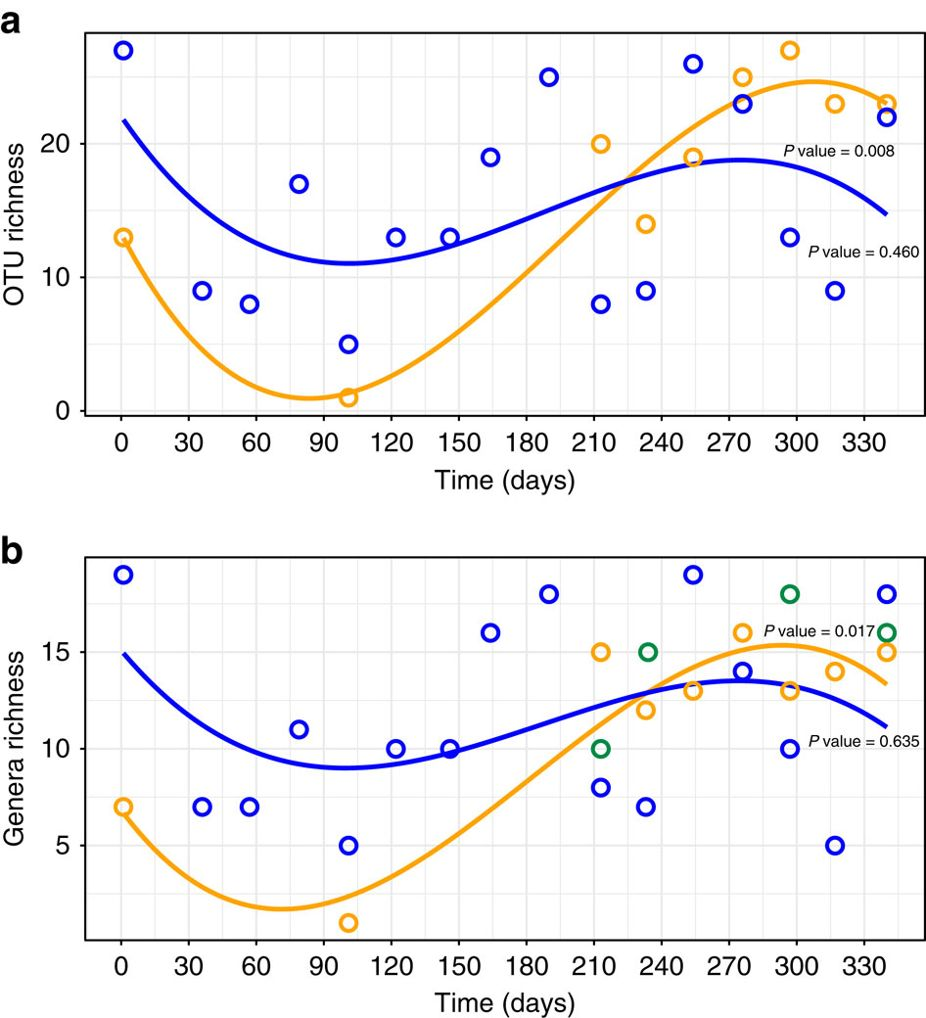

1. standardize OTU tables using Hellinger transformation (allows us to compare among sites more reliably)

```r
?decostand

Exuvia_Hel<-cbind(Exuvia[,1:5],decostand(Exuvia[,6:ncol(Exuvia)],method="hellinger"))

Water_Hel<-cbind(Water[,1:5],decostand(Water[,6:ncol(Water)],method="hellinger"))
```

We will work with genus level data. For this study genera and species were quite similar in their diversity patterns for this group. Here we used genera as it was a more reliable taxonomic assignment level for the metabarcoding data.

Convert OTU (eDNA) tables to genera tables (combine species in the same genera)

```r
OTUList_water<-OTUList[OTUList$OTU%in%colnames(Water_Hel)[6:ncol(Water_Hel)],]
OTUList_water<-OTUList_water[OTUList_water$Genus!="G",]

WaterGenera<-data.frame(matrix(ncol=length(unique(OTUList_water$Genus)),nrow=length(Water$SamplingID),dimnames=list(c(as.character(Water$SamplingID)),c(as.character(unique(OTUList_water$Genus))))))


for(i in colnames(WaterGenera)){
  for(j in rownames(WaterGenera)){

  Water[Water$SamplingID==j,which(colnames(Water)%in%OTUList_water[OTUList_water$Genus==i,"OTU"])]


    if(sum(Water[Water$SamplingID==j,which(colnames(Water)%in%OTUList_water[OTUList_water$Genus==i,"OTU"])])==0){WaterGenera[j,i]<-0}
    else if(sum(Water[Water$SamplingID==j,which(colnames(Water)%in%OTUList_water[OTUList_water$Genus==i,"OTU"])])>=1){WaterGenera[j,i]<-1}
    else{print("cat")}

  }
}

WaterGenera<-WaterGenera[,colnames(WaterGenera)[colnames(WaterGenera)!="G"]]

head(WaterGenera)
```

Exuvia table to genera table

```r
OTUList_Exuvia<-OTUList[OTUList$OTU%in%colnames(Exuvia_Hel)[6:ncol(Exuvia_Hel)],]
OTUList_Exuvia<-OTUList_Exuvia[OTUList_Exuvia$Genus!="G",]


ExuviaGenera<-data.frame(matrix(ncol=length(unique(OTUList_Exuvia$Genus)),nrow=length(Exuvia$SamplingID),
                                dimnames=list(c(as.character(Exuvia$SamplingID)),c(as.character(unique(OTUList_Exuvia$Genus))))))


for(i in colnames(ExuviaGenera)){
  for(j in rownames(ExuviaGenera)){

    Exuvia[Exuvia$SamplingID==j,which(colnames(Exuvia)%in%OTUList_Exuvia[OTUList_Exuvia$Genus==i,"OTU"])]


    if(sum(Exuvia[Exuvia$SamplingID==j,which(colnames(Exuvia)%in%OTUList_Exuvia[OTUList_Exuvia$Genus==i,"OTU"])])==0){ExuviaGenera[j,i]<-0}
    else if(sum(Exuvia[Exuvia$SamplingID==j,which(colnames(Exuvia)%in%OTUList_Exuvia[OTUList_Exuvia$Genus==i,"OTU"])])>=1){ExuviaGenera[j,i]<-1}
    else{print("cat")}

  }
}


head(ExuviaGenera)
```

Calculate alpha diversity (how many of each genera per sample) table for the Taxonomic (bulk sample), water samples (eDNA) and exuvia samples

The code is not perfect and uses rbind to ‘grow’ a data frame. This can lead to artificial growing if you are not careful with your script so it is a good idea to check your final length after each loop.

```r
#set up the data table format

AlphaTable<-data.frame(matrix(ncol=4,nrow=0,dimnames=list(c(),c("value","var","year","t_yday"))))

Water[,c("SamplingDay","Year")]


for(i in unique(Exuvia$SamplingID)){
  temp<-data.frame(value=specnumber(ExuviaGenera[rownames(ExuviaGenera)==i,]),
                   var="Exuviae",
                   year=2014,
                   t_day=Exuvia[Exuvia$SamplingID==i,"SamplingDay"])

  AlphaTable<-rbind(AlphaTable,temp)

  temp<-data.frame(value=specnumber(Exuvia[Exuvia$SamplingID==i,colnames(Exuvia)[which(colnames(Exuvia)%in%OTUList$OTU)]]),
                   var="Exuviae OTU",
                   year=2014,
                   t_day=Exuvia[Exuvia$SamplingID==i,"SamplingDay"])

  AlphaTable<-rbind(AlphaTable,temp)

}

for(i in unique(Water$SamplingID)){
  temp<-data.frame(value=specnumber(WaterGenera[rownames(WaterGenera)==i,]),

                   var="Water",
                   year=2014,
                   t_day=Water[Water$SamplingID==i,"SamplingDay"])
 AlphaTable<-rbind(AlphaTable,temp)

  temp<-data.frame(value=specnumber(Water[Water$SamplingID==i,colnames(Water)[which(colnames(Water)%in%OTUList$OTU)]]),
                   var="Water OTU",
                   year=2014,
                   t_day=Water[Water$SamplingID==i,"SamplingDay"])

  AlphaTable<-rbind(AlphaTable,temp)
}

colnames(Exuvia)[which(colnames(Exuvia)%in%OTUList$OTU)]


#OTU table - combine the alpha diversity values into a single table

OTU_mod<-data.frame(Alpha=AlphaTable[AlphaTable$var=="Exuviae OTU"|AlphaTable$var=="Water OTU","value"],
                    Method=AlphaTable[AlphaTable$var=="Exuviae OTU"|AlphaTable$var=="Water OTU","var"],
                     Time= AlphaTable[AlphaTable$var=="Exuviae OTU"|AlphaTable$var=="Water OTU","t_day"])


OTU_mod
```

statistical modeling (OTU richness)

cubic models first for the exuvia OTUs second for the water OTUs

```r
#exuvia otu diversity modeled over time

#subset the data (easier for coding the lm function)

x1e<-OTU_mod[OTU_mod$Method=="Exuviae OTU","Time"]
ye<-OTU_mod[OTU_mod$Method=="Exuviae OTU","Alpha"]
c1e<-lm(ye~poly(x1e,3))

#check the stats
anova(c1e)

#get the r square value
summary(c1e)$r.squared

#water (eDNA) otu diversity modeled over time

x1w<-OTU_mod[OTU_mod$Method=="Water OTU","Time"]
yw<-OTU_mod[OTU_mod$Method=="Water OTU","Alpha"]
c1w<-lm(yw~poly(x1w,3))

#check the stats
anova(c1w)

#get the r square value
summary(c1w)$r.squared


#calculate the predicted valuess for all time points (creating a smooth line for the plots)
OTUpredictse<-data.frame(fits=predict(c1e,newdata=data.frame(x1e=seq(from=1,to=340,by=1))),
                        time=seq(from=1,to=340,by=1))
OTUpredictsw<-data.frame(fits=predict(c1w,newdata=data.frame(x1w=seq(from=1,to=340,by=1))),
                         time=seq(from=1,to=340,by=1))

summary(c1e)
anova(c1e)
```

Creating top panel for Figure 3.

```r
#OTU
p1<-
   ggplot()+
  theme_bw()+
  geom_line(data=OTUpredictse,aes(x=time,y=fits),colour="orange",size=1.2)+
  annotate("text", x = 320, y = 19.8, label = paste("p-value"," = ","0.008",sep=""),size=2.5)+
  geom_line(data=OTUpredictsw,aes(x=time,y=fits),colour="blue",size=1.2)+
  annotate("text", x = 333, y = 11.8, label = paste("p-value"," = ","0.460",sep=""),size=2.5)+
  geom_point(data=OTU_mod,aes(x=Time,y=Alpha,colour=Method),size=3,shape=1,stroke=1.5)+
  scale_colour_manual( values = c("Water OTU"="blue", "Exuviae OTU"="orange"))+
  guides(colour="none")+
  scale_y_continuous(name="OTU Richness")+
  scale_x_continuous(name="Time(days)",breaks=seq(from=0,to=340,by=30))+
  theme(strip.text.x = element_text(size = 10))+ #facet header size
  theme(axis.text.x=element_text(size=10))+
  theme(axis.text.y=element_text(size=10))+
  theme(axis.title.x=element_text(size=15))+
  theme(axis.title.y=element_text(size=15,angle=90))
```

Now we calculate the statistics for the bottom panel for figure 3 (Genera diversity over time)

```r
#water, exuvia genera level

Gen_mod<-data.frame(Alpha=AlphaTable[AlphaTable$var=="Exuviae"|AlphaTable$var=="Water"|AlphaTable$var=="Taxon","value"],
                    Method=AlphaTable[AlphaTable$var=="Exuviae"|AlphaTable$var=="Water"|AlphaTable$var=="Taxon","var"],
                    Time= AlphaTable[AlphaTable$var=="Exuviae"|AlphaTable$var=="Water"|AlphaTable$var=="Taxon","t_day"])


#cubic polynomial for the exuvia genea data
xx1e<-Gen_mod[Gen_mod$Method=="Exuviae","Time"]
yye<-Gen_mod[Gen_mod$Method=="Exuviae","Alpha"]
c2e<-lm(yye~poly(xx1e,3))

#check stats
anova(c2e)
str(summary(c2e))

#r square value
summary(c2e)$r.squared

#cubic polynomial for the water (eDNA) genera data

xx1w<-Gen_mod[Gen_mod$Method=="Water","Time"]
yyw<-Gen_mod[Gen_mod$Method=="Water","Alpha"]
c2w<-lm(yyw~poly(xx1w,3))

#check the stats
anova(c2w)

#r square value
summary(c2w)$r.squared


#calculating the fitted curves
OTUpredictse2<-data.frame(fits=predict(c2e,newdata=data.frame(xx1e=seq(from=1,to=340,by=1))),
                          time=seq(from=1,to=340,by=1))
OTUpredictsw2<-data.frame(fits=predict(c2w,newdata=data.frame(xx1w=seq(from=1,to=340,by=1))),
                          time=seq(from=1,to=340,by=1))
```

Creating the bottom panel for figure 3

```r
p2<-
  ggplot()+
  theme_bw()+
  geom_line(data=OTUpredictse2,aes(x=time,y=fits),colour="orange",size=1.2)+
  annotate("text", x = 309, y = 16.15, label = paste("p-value"," = ","0.017",sep=""),size=2.5)+
  geom_line(data=OTUpredictsw2,aes(x=time,y=fits),colour="blue",size=1.2)+
  annotate("text", x = 327, y = 10.5, label = paste("p-value"," = ","0.635",sep=""),size=2.5)+
  geom_point(data=Gen_mod,aes(x=Time,y=Alpha,colour=Method),size=3,shape=1,stroke=1.5)+
  guides(colour=FALSE)+
  scale_colour_manual( values = c("Water"="blue", "Exuviae"="orange","Taxon"="springgreen4"))+
  scale_y_continuous(name="Genera Richness")+
  scale_x_continuous(name="Time(days)",breaks=seq(from=0,to=340,by=30))+
  theme(strip.text.x = element_text(size = 10))+ #facet header size
  theme(axis.text.x=element_text(size=10))+
  theme(axis.text.y=element_text(size=10))+
  theme(axis.title.x=element_text(size=15))+
  theme(axis.title.y=element_text(size=15,angle=90))
```

Creating a combined figure

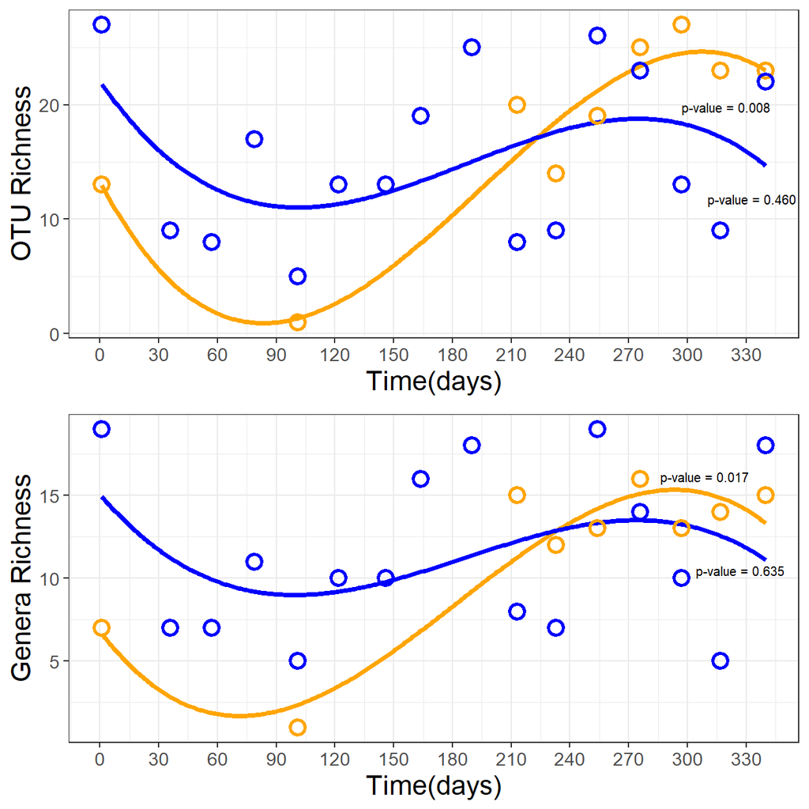

```r
#raster based
png(file="BistaFigure_3.png",width=1250,height=1250,res=200)

grid.arrange(arrangeGrob(p1,p2))

dev.off()

#vector based
pdf(file="BistaFigure_3.pdf",width=7,height=7)

grid.arrange(arrangeGrob(p1,p2))

dev.off()
```

We left out the free dots, which are the a subset of data that were not included in the models, but added for completeness in the figure and require a bit of extra indexing to add.